# Rapport de projet IF36 : Counter-Strike 2

2026-06-07

# Introduction

Bienvenue dans les coulisses de Counter-Strike 2. Les fichiers `.dem`, ces boîtes noires du jeu, ne sont pas de simples replays : ce sont des flux de données brutes, enregistrant chaque tick du serveur avec la précision d’un horloger suisse. Ici, CS2 n’est pas qu’une question de réflexes, c’est un générateur de données, où chaque poulet sacrifié sur Inferno, chaque “Have Fun” lancé dans le chat et chaque millimètre de déplacement est méticuleusement archivé.

**Notre mission ?** Analyser cet amas de données pour répondre à certaines questions. Par exemple, décrypter si la politesse est une stratégie gagnante : un “Have Fun” dans le chat, est-ce un buff de victoire ou juste une prière avant de se faire one-tap ? Ou encore trancher la plus grande superstition de l’e-sport : sacrifier des poulets sur Inferno, est-ce un rituel sacré ou juste une façon de polluer notre base de données avec des cadavres de volailles ?

**L’objectif final ?** Transformer ce chaos binaire en visualisations percutantes : heatmaps des zones de décès, efficacité des équipements selon l’économie, impact d’un clutch… Bref, donner un sens visuel à des milliers de ticks invisibles, pour révéler les schémas cachés derrière chaque victoire. En résumé, prouver que derrière chaque “GG”, chaque “EZ” et chaque poulet explosé, il y a une donnée qui attend d’être exploitée.

## Information générale concernant Counter-Strike 2

#### Structure d’une partie

Une partie se déroule en 24 rounds maximum. La première équipe qui remporte 13 rounds gagne la partie. Après 12 rounds, les équipes inversent leurs rôles. En cas d’égalité 12-12, des prolongations départagent les équipes.

#### Objectifs par camp

Les **Terroristes (T)** doivent soit poser la bombe sur l’un des deux sites et la faire exploser, soit éliminer tous les adversaires. Les **Contre-Terroristes (CT)** doivent empêcher la pose, désamorcer la bombe si elle est posée, ou éliminer tous les adversaires avant la fin du temps imparti.

#### Gestion économique

Chaque action (victoire, défaite, élimination, pose ou désamorçage de bombe) rapporte de l’argent. Au début de chaque round, les joueurs l’utilisent pour acheter armes, protections et grenades. Si une équipe manque d’argent, elle peut faire un round “eco” (acheter peu ou rien) afin d’économiser pour s’équiper complètement au round suivant.

#### Déroulement d’un round

Un round dure 1 minute et 55 secondes : 15 secondes de phase d’achat, puis une phase de jeu fondée sur les objectifs de chaque camp. Si la bombe est posée, le chronomètre passe à 40 secondes, et les CT doivent la désamorcer avant qu’elle n’explose.

## Données

### Type de données

Notre dataset s’appuie sur les **fichiers de démo (`.dem`)** de Counter-Strike 2, qui permettent une reconstitution fidèle de chaque match. Ces fichiers enregistrent l’intégralité des données de jeu : de l’évolution du score aux déplacements précis des joueurs, jusqu’aux interactions avec l’environnement comme les mouvements des poulets. C’est cette précision qui justifie notre choix d’exploiter ce format.

### Provenance des données

Nos fichiers proviennent du site [**HLTV**](https://www.hltv.org/), référence mondiale dédiée à l’actualité, aux statistiques et à la couverture compétitive de Counter-Strike. Nous disposons de **522 fichiers de démos**, répartis sur huit cartes :

| Échantillons | Carte |
| --- | --- |
| 103 | de_mirage |
| 95 | de_ancient |
| 86 | de_dust2 |
| 79 | de_nuke |
| 61 | de_inferno |
| 51 | de_overpass |
| 37 | de_anubis |
| 10 | de_train |

### Structure du pipeline de données

Le traitement suit un flux automatisé en plusieurs étapes.

**Collecte** : récupération des archives `.rar` contenant les démos depuis les serveurs de HLTV, chaque archive correspondant à un match.

**Extraction** : décompression pour isoler les fichiers `.dem`, format brut des données de match.

**Analyse et stockage** : utilisation de l’outil [**CSDM (CS Demo Manager)**](https://cs-demo-manager.com/) pour parser les fichiers et extraire les événements de jeu (kills, positions, économie, tirs, dégâts…), structurés puis injectés dans une base **PostgreSQL**.

**Déploiement** : mise à disposition via un conteneur PostgreSQL couplé à l’interface CloudBeaver.

Pour chaque question du rapport, les données nécessaires sont extraites de cette base sous forme de fichiers `.csv`, présentés au fil de l’analyse via les requêtes SQL correspondantes.

## Plan d’analyse

Counter-Strike est un jeu qui soulève sans cesse des questions quand on y joue : un placement, une arme, un timing, une dépense d’argent, beaucoup d’intuitions que l’on accumule partie après partie, mais que l’on ne vérifie presque jamais. La question qui guide notre travail est donc la suivante : **dans quelle mesure ces données peuvent-elles répondre aux interrogations d’un joueur, voire en dégager de véritables tendances stratégiques et améliorer son expérience du jeu ?** Autrement dit, en fouillant ces milliers de ticks, peut-on faire émerger une meilleure compréhension du jeu qui permettrait notamment de perfectionner la pratique du jeu?

Nous avons regroupé nos questions en plusieurs parties:

**I - Mirage, cas d’étude** **II - Sites, bombes & stratégies** **III - Armes & dynamique des rounds** **IV - On s’amuse**

### Quelques précautions

Quelques précautions avant d’entrer dans l’analyse. Nos données proviennent exclusivement du jeu professionnel : nos conclusions décrivent le haut niveau et ne se transposent pas forcément à une partie classique. Et comme le vocabulaire de CS peut rebuter les non-initiés, un glossaire est fourni en annexe.

# Exploration

Counter-Strike soulève sans cesse des questions quand on y joue : un placement, une arme, un timing, une dépense d’argent. Beaucoup d’intuitions s’accumulent partie après partie sans jamais être vérifiées. Nous avons regroupé notre exploration en quatre parties. Nous ouvrons sur une étude de cas approfondie d’une carte (**Mirage**), puis nous élargissons à trois familles de facteurs qui décident d’un round : le contrôle des **sites et de la bombe**, l’**arsenal et l’économie**, et enfin les **croyances de joueurs**. L’objectif est de montrer que l’équilibre de CS ne tient pas d’une symétrie parfaite, mais d’un compromis entre styles de jeu et phases de round.

# I - Mirage, cas d’étude

Nous commençons par une exploration approfondie d’une seule carte, *Mirage*, la plus représentée dans notre jeu de données (103 matchs). L’idée est de confronter une croyance répandue parmi les joueurs (certaines cartes favoriseraient un camp en raison de leur design) à des données issues de parties réelles, puis de pousser jusqu’à une analyse spatiale fine des affrontements.

Afin de simplifier la lecture des graphiques, nous adopterons les conventions suivantes :

- Les Terroristes seront représentés par la couleur **orange**
- Les Anti-Terroristes seront représentés par la couleur **bleue**

*Mirage* est souvent perçue par les joueurs comme **favorable aux Anti-Terroristes**. C’est cette intuition que nous allons mettre à l’épreuve.

*La même analyse pourrait être reproduite sur les autres cartes : il suffirait de modifier les fichiers CSV utilisés.*

Notre processus repose sur l’extraction de fichiers `.csv` depuis notre base de données à l’aide de requêtes SQL, présentées à chaque fois qu’un nouveau fichier est introduit.

## La carte Mirage favorise-t-elle un camp ?

### Est-ce qu’un camp gagne plus de rounds que l’autre ?

Dans un premier temps, nous récupérons l’ensemble des rounds joués sur *Mirage* afin d’observer la proportion de rounds remportés par chaque camp.

**rounds_de_mirage.csv**

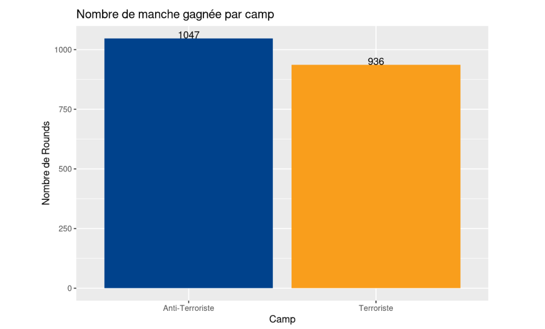

```sql
CREATE TABLE csdm.public.round_de_mirage
AS SELECT *
FROM rounds WHERE match_checksum
IN ( SELECT checksum FROM demos WHERE map_name = 'de_mirage' )
```

Sur le papier, et compte tenu du nombre limité de matchs disponibles (103 matchs), la différence observée reste relativement faible. On peut alors se demander si cette tendance devient plus significative lorsque l’on considère le nombre de rounds gagnés par match, plutôt que le total brut.

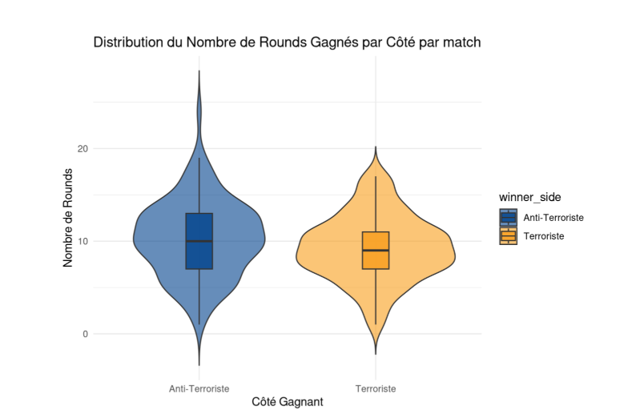

D’un point de vue statistique, il est difficile de conclure à une différence significative entre les deux camps. La dispersion des valeurs est importante, comme le montre l’étendue des distributions, ce qui limite la capacité à identifier un avantage clair.

Il est donc nécessaire d’aller plus loin dans l’analyse afin de déterminer si un éventuel avantage en faveur des Anti-Terroristes peut être mis en évidence de manière plus robuste.

### Est-ce que les kills expliquent cet avantage ?

Nous cherchons maintenant à déterminer si les kills peuvent expliquer un éventuel avantage observé entre les deux camps. Dans un premier temps, nous récupérons les informations relatives aux kills.

**kills_de_mirage.csv**

```sql
CREATE TABLE csdm.public.kill_de_mirage
AS SELECT killer_x, killer_y, killer_z, victim_x, victim_y, victim_z,
killer_side, victim_side, match_checksum
FROM kills WHERE match_checksum
IN ( SELECT checksum FROM demos WHERE map_name = 'de_mirage' )
```

#### Un camp fait-il plus de kills que l’autre ?

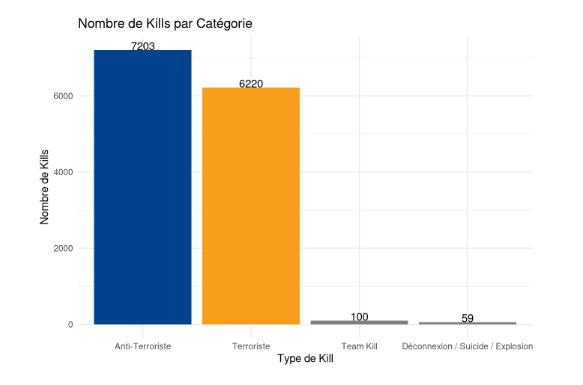

On observe une différence d’environ 1 000 kills, ce qui peut être significatif dans l’économie d’une partie. Toutefois, afin de s’assurer de la pertinence de cette observation, nous allons rapporter le nombre de kills au nombre de kills par camp et par match.

#### Y a-t-il une différence de kills par match ?

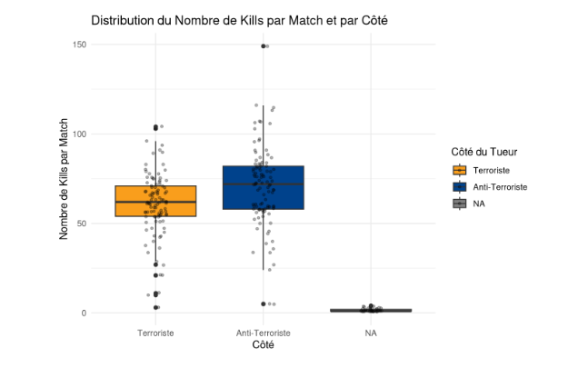

*Les valeurs NA correspondent aux autres types de kills ne résultant pas d’un affrontement direct entre les deux équipes.*

De même que pour le nombre moyen de manches gagnées par match, la variabilité des données ne permet pas de conclure clairement à un avantage d’un camp sur l’autre. On peut éventuellement conjecturer un léger avantage en faveur des Anti-Terroristes, mais les résultats ne sont pas suffisamment robustes pour en tirer une conclusion définitive.

## Analyse spatiale : la carte influence-t-elle les combats ?

À partir de ce point, nous utilisons une terminologie associée aux différentes zones de la carte. Une carte annotée est fournie afin de faciliter la compréhension des analyses qui suivent.

Par ailleurs, nous avons mis en place un masque pour simplifier l’affichage des graphiques. Nous avons utilisé la carte *Mirage* disponible dans notre jeu de données, en conservant les zones utiles *(blanches)* et en rendant le fond *(zones jouables)* transparent. Ce masque est ensuite appliqué sur les graphiques afin de ne conserver que les zones pertinentes pour l’analyse.

**Algorithme python pour la génération du masque**

```python
def process_image_for_white_and_transparent(input_path, output_path,
white_threshold=240):
    img = cv2.imread(input_path, cv2.IMREAD_UNCHANGED)
    if img is None:
        raise FileNotFoundError(f"Impossible de lire l'image : {input_path}")
    if img.shape[2] == 3:
        img = cv2.cvtColor(img, cv2.COLOR_BGR2BGRA)
    bgr = img[:, :, 0:3]
    alpha_orig = img[:, :, 3]
    hsv = cv2.cvtColor(bgr, cv2.COLOR_BGR2HSV)
    lower_white = np.array([0, 0, white_threshold])
    upper_white = np.array([180, 255, 255])
    mask_white = cv2.inRange(hsv, lower_white, upper_white)
    mask_transparent = (alpha_orig == 0).astype(np.uint8) * 255
    pixels_to_become_white = cv2.bitwise_or(mask_white, mask_transparent)
    output_bgr = np.zeros_like(bgr, dtype=np.uint8)
    output_alpha = np.zeros_like(alpha_orig, dtype=np.uint8)
    output_bgr[pixels_to_become_white == 255] = [255, 255, 255]
    output_alpha[pixels_to_become_white == 255] = 255
    result_rgba = cv2.merge([output_bgr[:, :, 0], output_bgr[:, :, 1], output_bgr[:, :, 2],
    output_alpha])
    cv2.imwrite(output_path, result_rgba)

input_image_original = "de_mirage.png"
output_image_processed = "de_mirage_processed.png"
process_image_for_white_and_transparent(input_image_original, output_image_processed)
```

*Nous avons ensuite retravaillé ces images afin de les rendre plus propres, notamment en supprimant certains pixels noirs résiduels présents dans les zones blanches de la carte.*

### Où sont posées les bombes ?

Nous commençons par récupérer les informations relatives aux bombes plantées, afin d’identifier les zones de plant privilégiées par les Terroristes.

**bomb_de_mirage.csv**

```sql
DROP TABLE IF EXISTS csdm.public.bomb_de_mirage;
CREATE TABLE csdm.public.bomb_de_mirage AS
WITH mirage_matches AS (
SELECT checksum
FROM demos
WHERE map_name = 'de_mirage'
),
planted AS ( /*Permet de crée des 'tables' temporaires dans la requête*/
SELECT
bp.match_checksum,
bp.round_number,
bp.x,
bp.y
FROM bombs_planted bp
WHERE bp.match_checksum IN (SELECT checksum FROM mirage_matches)
),
exploded AS (
SELECT
match_checksum,
round_number
FROM bombs_exploded
WHERE match_checksum IN (SELECT checksum FROM mirage_matches)
),
defused AS (
SELECT
match_checksum,
round_number
FROM bombs_defused
WHERE match_checksum IN (SELECT checksum FROM mirage_matches)
)
SELECT
p.match_checksum,
p.round_number,
p.x,
p.y,
CASE
WHEN e.match_checksum IS NOT NULL THEN 'exploded'
WHEN d.match_checksum IS NOT NULL THEN 'defused'
ELSE 'planted_only'
END AS bomb_status
FROM planted p /*On peut donc les réutiliser ici*/
LEFT JOIN exploded e
ON p.match_checksum = e.match_checksum
AND p.round_number = e.round_number
LEFT JOIN defused d
ON p.match_checksum = d.match_checksum
AND p.round_number = d.round_number;
```

#### Tout d’abord, est-ce que les Terroristes jouent souvent la bombe sur Mirage ?

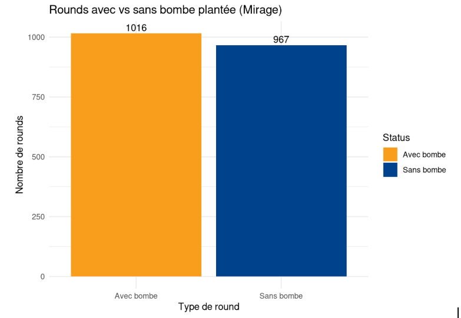

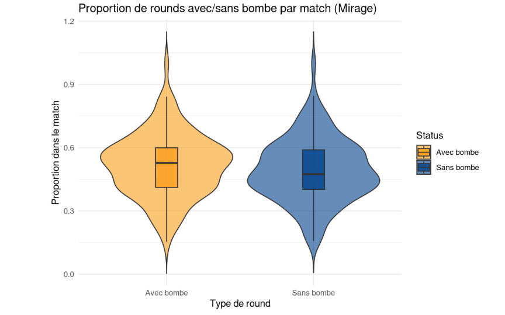

La distribution des proportions de rounds avec et sans bombe par match reste relativement stable, indiquant que la structure des matchs est globalement homogène sur cet aspect. On observe néanmoins une certaine variabilité, suggérant des styles de jeu légèrement différents selon les rencontres.

Nous allons toutefois analyser l’issue des rounds en fonction de la pose ou non de la bombe.

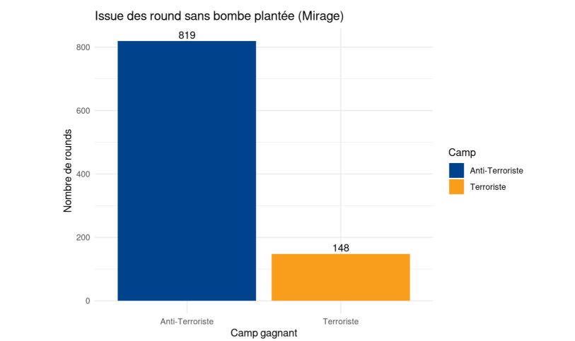

Lorsque la bombe n’est pas plantée, l’avantage semble revenir aux Anti-Terroristes. Leur position de défense et leur capacité de temporisation peuvent expliquer ce résultat.

*Pour confirmer cette observation, il serait pertinent d’analyser plus en détail les durées des rounds, les conditions de victoire, ainsi que la proportion de rounds se terminant par l’élimination complète de l’équipe adverse.*

#### Emplacement de prédilection pour les bombes ?

[figure not shown]

Les règles du jeu imposent le placement de la bombe dans des zones dédiées, appelées sites A et B. Cependant, on observe que le site B présente une zone particulièrement utilisée pour le plant.

Mais cette tendance correspond-elle à une stratégie réellement gagnante ?

#### Est-ce que les bombes servent réellement ?

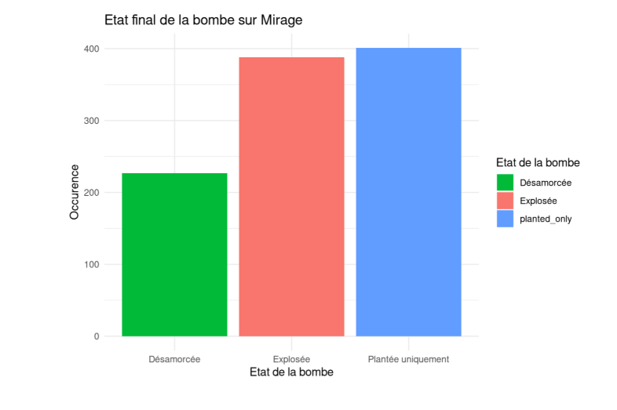

On remarque que les bombes sont moins souvent désamorcées que dans les autres cas (explosions ou absence de désamorçage après avoir été plantées). Cette tendance est-elle similaire pour chaque site ?

#### Quelle issue pour les bombes sur chaque site ?

Nous allons utiliser un algorithme de *k-means* afin d’identifier les clusters et d’estimer la proportion de chaque type d’issue en fonction du site sur lequel on se trouve.

Par analyse visuelle de la carte, il est possible d’associer le cluster 1 au site A et le cluster 2 au site B.

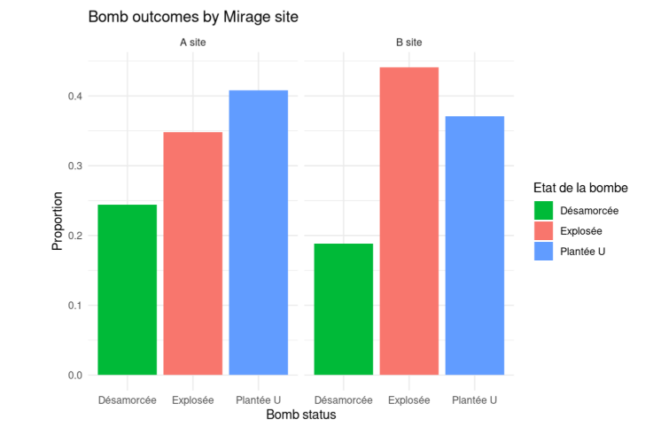

L’analyse des issues de bombe montre une différence de comportement entre les deux sites.

Sur le site B, les explosions sont plus fréquentes que les simples situations de bombe plantée, ce qui indique des situations où la défense intervient moins efficacement avant l’issue du round.

Dans les deux cas, les désamorçages représentent systématiquement l’issue la moins fréquente, ce qui confirme que la pose de bombe tend globalement à favoriser les Terroristes, indépendamment du site.

#### Quel est le taux de victoires pour chaque site avec pose de bombes ?

En considérant que les Terroristes remportent le round lorsque la bombe explose ou reste simplement plantée, et que les Anti-Terroristes gagnent en cas de désamorçage, nous pouvons comparer les taux de victoire selon les sites.

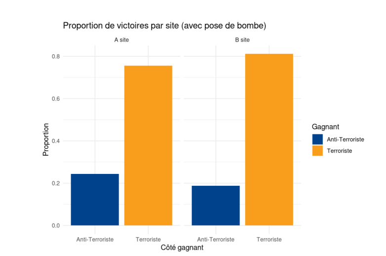

Dès qu’une bombe est plantée, l’avantage bascule en faveur des Terroristes, que ce soit sur le site A ou sur le site B. À l’inverse, en l’absence de bombe, l’avantage revient aux Anti-Terroristes.

On peut donc conclure que la présence de la bombe constitue un facteur déterminant dans l’issue d’un round, indépendamment de son emplacement. La défense et la temporisation apparaissent comme les stratégies les plus efficaces pour les Anti-Terroristes, tandis que les Terroristes prennent l’avantage une fois la bombe amorcée.

### Où meurent et où tuent les joueurs ?

**Fonction pour l’affichage des cartes de densité**

[figure not shown]

[figure not shown]

Ici, on n’observe pas de différence marquée entre les zones où se trouvent les tueurs et celles où se trouvent les victimes. Les densités restent globalement similaires sur l’ensemble de la carte.

On observe des zones clés *(de forte concentration)* telles que Connector, Stairs, Shadow, Palace, Tetris, Short ou encore Balcony, des espaces connus des joueurs comme étant des points de confrontation fréquents.

Une différence notable est la hausse de la densité sur la carte des morts au niveau de Top Mid. Un endroit réputé pour être une ligne favorable à l’affrontement au centre de la carte entre les Anti-Terroristes et les Terroristes. Mais est-ce une ligne utilisée ?

### Distance moyenne de kill ?

Nous allons maintenant analyser ces mêmes cartes en distinguant les camps afin d’affiner l’interprétation.

### Y a-t-il une différence selon le camp ?

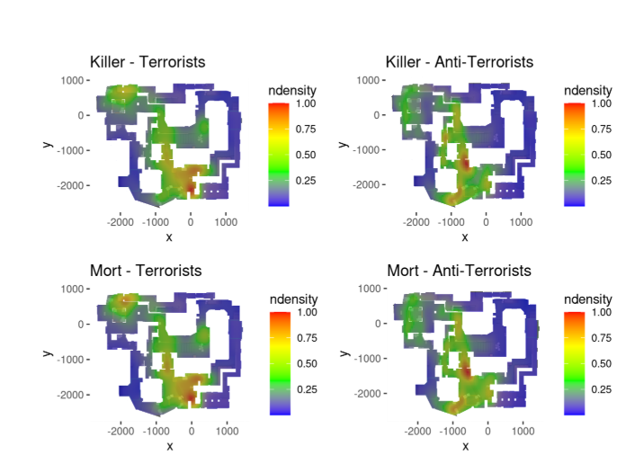

On observe des cartes de chaleur similaires dans leur structure globale. Cependant, les zones les plus marquées ne sont pas identiques selon les camps. Chez les Terroristes, on observe une forte concentration de morts au niveau de Top Mid, Palace et Tetris, tandis que chez les Anti-Terroristes, celles-ci se situent davantage au niveau de Window, Stairs et Ticket.

On remarque que les deux équipes partagent une zone centrale commune, ainsi que quelques zones plus spécifiques situées de part et d’autre de la carte selon le camp. On peut alors se demander s’il est pertinent de diviser la carte en deux zones distinctes afin de mieux caractériser ces différences de contrôle et d’engagement.

**Mise en perspective**

*Le site HLTV propose aussi des visuels avec heatmaps pour Mirage. Ils possèdent un plus grand nombre d’observations, cependant on converge vers une solution qui ressemble à la leur même avec moins d’observations. Voici le lien pour aller consulter leur proposition de heatmaps :* [Counter-Strike Statistics database | HLTV.org](https://www.hltv.org/stats/maps/map/32/Mirage?showKills=true&showDeaths=false&firstKillsOnly=false&allowEmpty=false&showKillDataset=true&showDeathDataset=false). Nous pouvons alors décemment nous permettre de faire des généralités concernant ces cartes de chaleur.

*Avant d’envisager une segmentation de la carte, nous allons dans un premier temps analyser les lignes de tir, afin de déterminer si certaines orientations ou trajectoires sont plus favorables à un camp en particulier.*

## Analyse avec algorithmes de Data Analyse

### Quelles sont les directions des kills ?

Nous allons dans un premier temps reconstruire les vecteurs associés aux éliminations, afin d’analyser les directions des tirs mortels.

### Existe-t-il des lignes de tir récurrentes ?

Nous utilisons ensuite l’algorithme de clustering DBSCAN afin d’identifier d’éventuelles trajectoires de tirs récurrentes. L’objectif est de mettre en évidence les vecteurs les plus fréquemment observés. Les hyperparamètres ont été choisis de manière empirique.

*Ce clustering peut être débattu, dans la mesure où une grande partie des points n’est pas regroupée et est considérée comme du bruit. Cependant, étant donné la nature du rendu (un document PDF), l’augmentation du nombre de clusters nuirait à la lisibilité des graphiques (qui sont déjà assez compliqués à lire). Nous avons donc retenu ce partitionnement comme compromis entre interprétabilité et richesse de l’information.*

*Il est laissé à la discrétion du lecteur d’expérimenter d’autres paramètres afin de tirer ses propres conclusions. Une analyse plus poussée et un travail d’optimisation des hyperparamètres seraient nécessaires pour exploiter pleinement cette approche.*

On observe en effet qu’un nombre important d’observations est classé comme bruit. Il serait possible d’ajuster les paramètres afin de rendre le clustering plus inclusif, mais cela risquerait de dégrader la pertinence des groupes identifiés en introduisant une trop forte variabilité au sein des clusters.

[figure not shown]

On retrouve plusieurs lignes connues des joueurs, notamment la ligne de Window vers Top Mid, ainsi que des échanges à double sens entre Tetris et Ticket, ou encore entre Palace et Tetris.

*Dans cette analyse, l’axe Z n’est pas pris en compte. Ce choix est motivé par le fait que cette dimension est difficile à représenter de manière lisible et qu’elle n’apporte qu’une information limitée à quelques situations spécifiques, notamment sur des positions comme Van vers Balcony ou encore la distinction entre Shadow et Palace.*

Reste alors à déterminer à quel camp bénéficie chaque trajectoire de tir.

### Quel camp domine chaque cluster ?

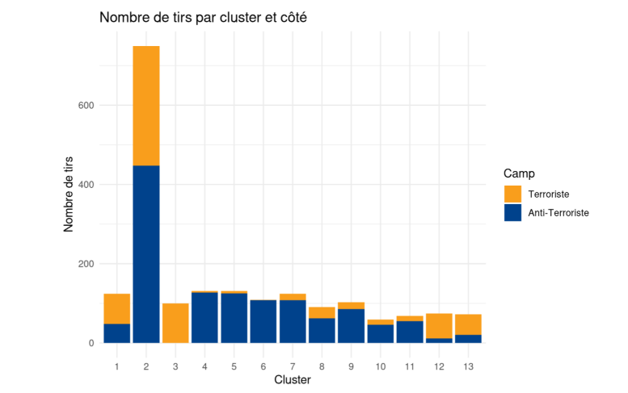

On observe que certaines lignes sont davantage utilisées par les Anti-Terroristes ou par les Terroristes. Cela peut s’expliquer par leur orientation, souvent dirigée vers des positions contrôlées par le camp adverse.

Certaines trajectoires sont ainsi majoritairement exploitées par les Anti-Terroristes, ce qui pourrait contribuer à expliquer leur léger avantage mis en évidence dans les analyses précédentes.

On remarque notamment que la ligne 6 (Window vers Top Mid) semble conférer un avantage aux Anti-Terroristes. Cette observation vient confirmer l’hypothèse formulée à partir des heatmaps.

Cependant, cela soulève une question plus générale : existe-t-il réellement des zones de jeu distinctes entre les deux camps ?

[figure not shown]

*Ce résultat est à prendre avec précaution, ici la coloration se base sur le camp dominant, mais ne tient pas compte de la répartition exacte, il suffit d’un tir de différence pour que la couleur change.*

### Peut-on séparer la carte en deux zones distinctes en fonction des deux camps par rapport à leurs morts / kills ?

#### Killer

Ici nous avons pris la décision de faire un SVM linéaire, on pourrait étoffer avec un non linéaire, mais pour notre étude cela suffira.

[figure not shown]

#### Victim

[figure not shown]

Si on superpose ces deux droites on obtient le graphique suivant :

#### Superposition

[figure not shown]

On observe l’apparition d’un *no man’s land* au centre de la carte. La superposition avec les autres visualisations permet de mettre en évidence des éléments particulièrement intéressants concernant la répartition des engagements entre les deux camps.

## On s’amuse ?

[figure not shown]

On observe que les lignes naissent dans l’un ou l’autre camp et qu’à une exception près, leur camp d’origine détermine celui qui les utilise le plus.

[figure not shown]

[figure not shown]

On observe que les zones de forte densité se concentrent majoritairement au sein du *no man’s land*. En croisant ces résultats avec les visualisations séparant les densités par camp, il apparaît que les principaux pics de densité propres à chaque équipe se situent de part et d’autre de cette zone centrale.

## Conclusion du cas Mirage

L’étude de *Mirage* permet de mettre en évidence une dynamique structurée entre Terroristes et Anti-Terroristes, mais aussi un déséquilibre dans la manière dont chaque camp contrôle la carte.

À première vue, les résultats globaux sur les rounds et les kills ne montrent pas de déséquilibre important. Cependant, dès que l’on entre dans une analyse spatiale et comportementale, une tendance apparaît : les Anti-Terroristes disposent d’un réseau de positions et de lignes de tir qui sont à leur avantage. Cette organisation leur permet de mieux contrôler l’espace et de multiplier les points d’engagement défensifs.

À l’inverse, les Terroristes semblent moins présents en termes de diversité de lignes, mais leurs actions sont plus orientées vers un objectif précis : la prise de site et l’exploitation du post-plant. Cette différence de logique explique pourquoi les deux camps peuvent apparaître équilibrés au niveau global, malgré des avantages locaux différents.

Un point important ressort : dès que la bombe est posée, l’avantage bascule en faveur des Terroristes, ce qui confirme le poids central de cette mécanique dans l’issue des rounds. À l’opposé, lorsque la bombe n’est pas plantée, les Anti-Terroristes reprennent l’avantage grâce à leur capacité de contrôle et de temporisation.

Enfin, les analyses de clustering et de densité montrent que les engagements ne sont pas répartis aléatoirement, mais suivent des structures récurrentes et des zones de friction bien identifiées. Cela renforce l’idée que l’équilibre de Mirage ne vient pas d’une symétrie parfaite, mais d’un compromis entre deux styles de jeu opposés.

**En résumé :**

- Les Anti-Terroristes dominent le contrôle spatial et les lignes de tir.
- Les Terroristes dominent les situations de post-plant.
- L’équilibre global de la carte résulte de cette opposition de styles plutôt que d’une égalité parfaite sur tous les aspects.

Ainsi, *Mirage* n’est pas une carte déséquilibrée, mais une carte où l’avantage dépend du contexte du round et de la capacité de chaque camp à imposer sa phase de jeu.

# II - Sites, bombes & stratégies

Après avoir étudié une carte en profondeur, nous élargissons la focale à l’ensemble des cartes pour interroger le plant de la bombe et les choix tactiques qui l’entourent : quel site mène le plus souvent à la victoire des Terroristes, la bombe plantée fait-elle réellement basculer un round, une smoke bien placée change-t-elle le rapport de force, et la grenade est-elle l’arme d’un camp plutôt que de l’autre.

## Quel site mène le plus souvent à la victoire des Terroristes ?

Pour répondre à cette question, on regarde si les bombes qui ont explosé ont été davantage plantées sur le site A ou le site B, en fonction des différentes cartes.

**Attendu des résultats.** Au niveau des résultats, on peut s’attendre à une bonne répartition, et dans le cas contraire cela signifierait un manque d’équilibre dans le jeu.

**Récupération des données.** Il n’y aura pas de tri en fonction de la victoire des Terroristes, car on considère que l’explosion d’une bombe signifie toujours la victoire des Terroristes sur le round.

```sql
SELECT
demos.map_name,
bombs_exploded.site,
COUNT(*) AS nb_explosions
FROM bombs_exploded
JOIN demos ON bombs_exploded.match_checksum = demos.checksum
GROUP BY demos.map_name, bombs_exploded.site
ORDER BY demos.map_name, nb_explosions DESC;
```

Ainsi nous obtenons un tableur de 16 entrées avec chacune 3 valeurs : map_name, site et nb_explosions.

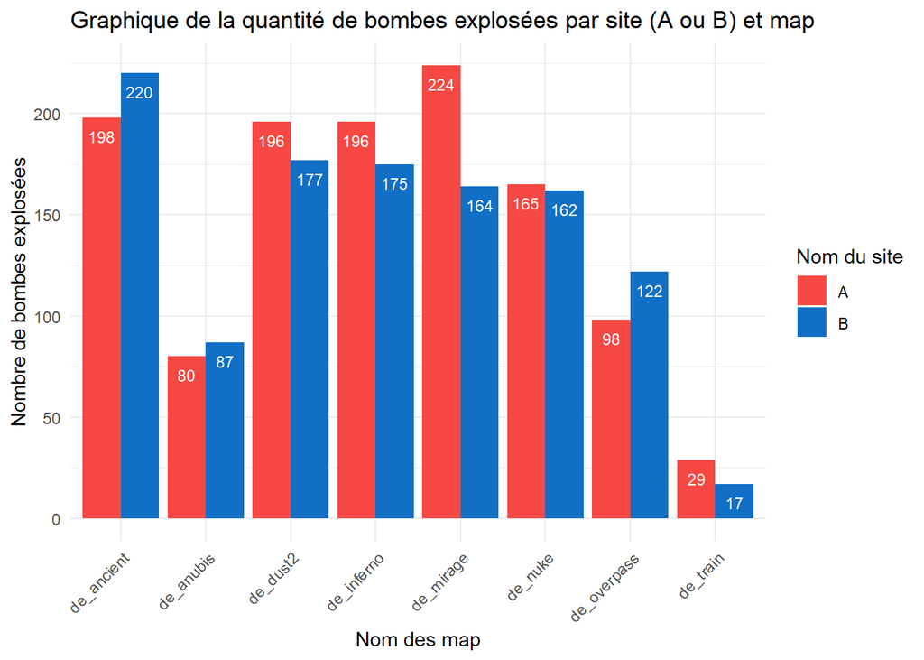

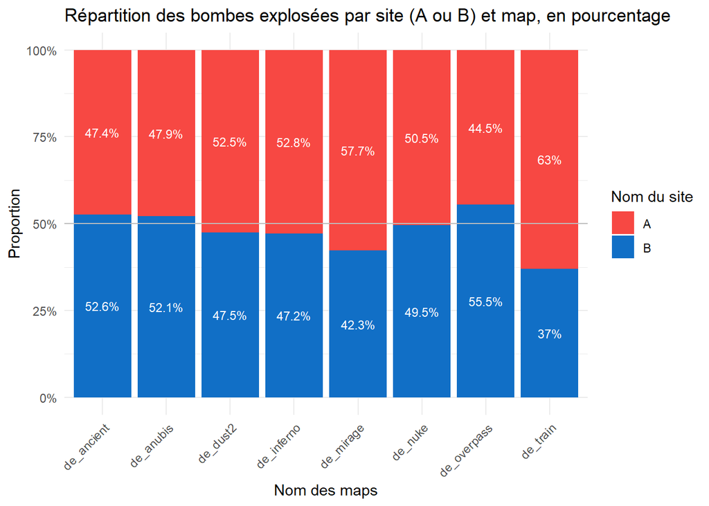

Avec ces résultats, on peut déduire qu’il n’y a pas vraiment de site à privilégier pour l’activation de la bombe, mais ces graphiques ne permettent pas de savoir si les joueurs ont une préférence pour un site ou l’autre, et qui pourrait expliquer les variations de pourcentage.

**Attendu des résultats.** Pour avoir des résultats les plus complets possibles, il faudrait donc comparer la quantité de bombes posées à celles de bombes désamorcées et celles ayant explosé. Avec cela, on pourra faire parler correctement les données, savoir s’ils se font plus désamorcer la bombe sur l’un des sites, ou encore si tout simplement les joueurs privilégient certains sites.

**Récupération des données.**

```sql
SELECT
demos.map_name,
bombs_planted.site,
COUNT(DISTINCT bombs_planted.id) AS nb_plantees,
COUNT(DISTINCT bombs_exploded.id) AS nb_explosees,
COUNT(DISTINCT bombs_defused.id) AS nb_desamorcees
FROM bombs_planted
JOIN demos ON bombs_planted.match_checksum = demos.checksum
LEFT JOIN bombs_exploded
ON bombs_exploded.match_checksum = bombs_planted.match_checksum
AND bombs_exploded.round_number = bombs_planted.round_number
AND bombs_exploded.site = bombs_planted.site
LEFT JOIN bombs_defused
ON bombs_defused.match_checksum = bombs_planted.match_checksum
AND bombs_defused.round_number = bombs_planted.round_number
AND bombs_defused.site = bombs_planted.site
GROUP BY demos.map_name, bombs_planted.site
ORDER BY demos.map_name, bombs_planted.site;
```

Similairement à la requête précédente, il y a 16 entrées mais avec 2 colonnes supplémentaires comparé à la précédente : l’une pour les bombes plantées et l’autre pour les bombes désamorcées.

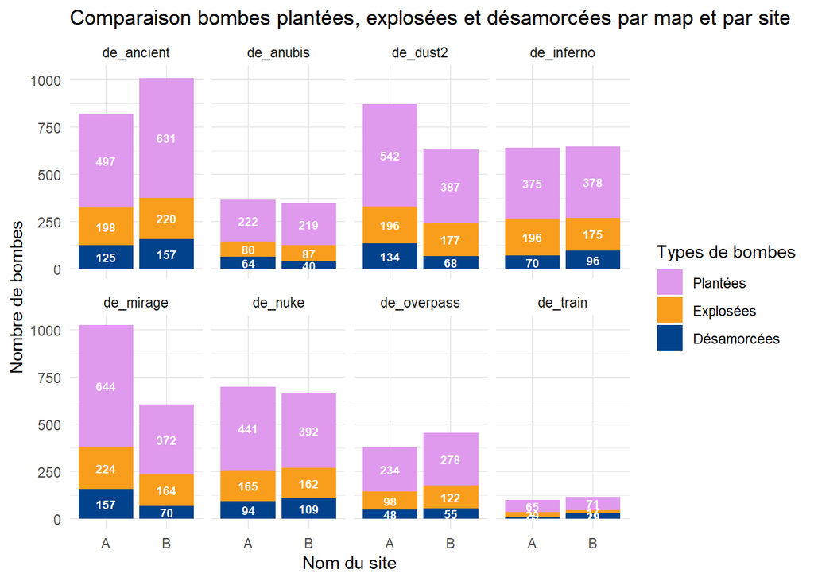

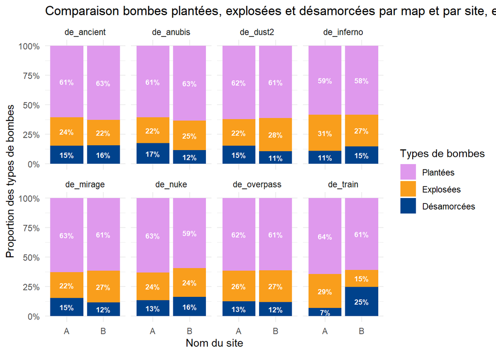

**Conclusion.** Vu que les proportions de désamorçage et d’explosion sont globalement toutes similaires, carte et site confondus, on peut en conclure que Counter-Strike 2 est très équilibré sur ce point, car il n’y a pas de site favorisant significativement les joueurs poseurs de bombes. La réussite du round ne repose donc pas tant sur la sélection du site en tant que tel, mais bien plus sur la situation en jeu et la stratégie que les 2 équipes auront.

## Une smoke près du bombsite change-t-elle le rapport de force ?

On se demande si lorsqu’un joueur pose une bombe smoke (fumigène) près d’un site de bombe, cela augmente la probabilité que les Terroristes gagnent en posant la bombe. On a donc pris, pour chaque manche où une bombe smoke a été utilisée, le taux de victoire des Terroristes. On a aussi restreint les observations aux smokes posées près des sites de bombes, mais en n’ayant les résultats que pour 4 cartes, car il faut renseigner à la main les coordonnées de chaque site de bombe. On obtient donc ces bar charts :

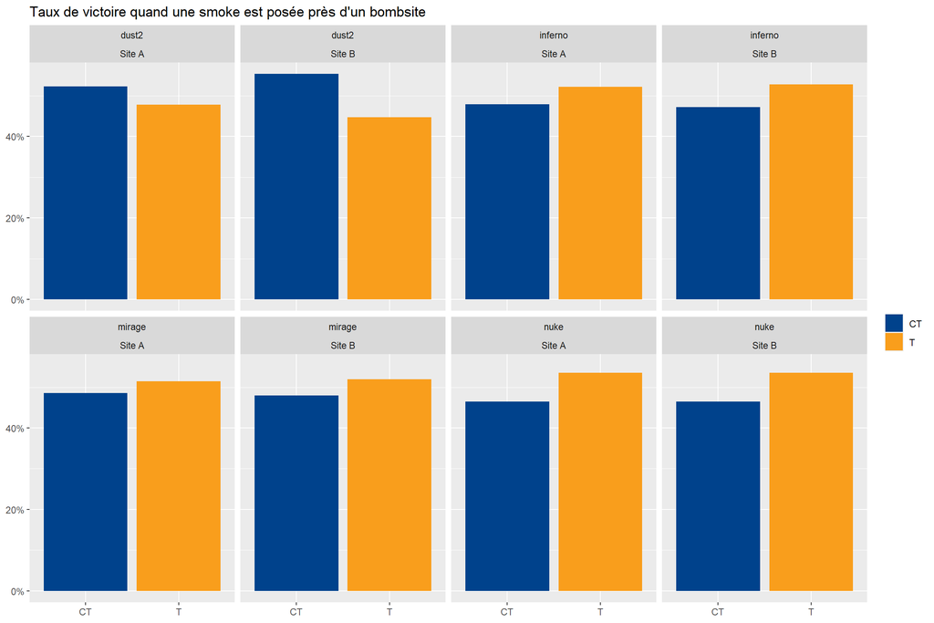

On voit donc bien qu’il y a un taux de victoire plus élevé pour les Terroristes sur 3 des 4 cartes, mais pas pour dust2. Cela pourrait venir du fait que les CT gagnent en général plus souvent sur cette carte, et cela n’a pas été pris en compte dans la visualisation. Il faudrait donc recommencer la visu, en comparant le taux de victoire d’une manche quand une smoke est posée avec le taux de victoire d’une manche en général.

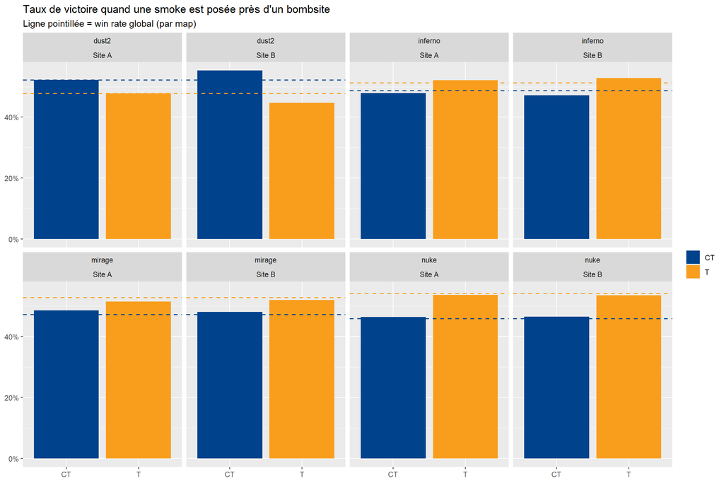

En ajoutant le winrate global, on remarque finalement que le winrate est largement influencé par la carte, et que le fait de lancer une bomb smoke sur le site A ou B ne change pas beaucoup le winrate, sauf pour la carte dust2 où cette stratégie favorise les Contre-Terroristes.

## La grenade est-elle plus utilisée par les Terroristes ou les Contre-Terroristes ?

Cette question est intéressante pour comprendre qui, globalement, utilise le plus ce type d’arme. Cela comprend les différents types de grenades, donc fumigènes, explosifs, etc. Il va ainsi falloir mettre en évidence l’utilisation des grenades par chaque camp, puis les représenter et les interpréter. On aura peut-être une représentation différente suivant les cartes.

**Attendu des résultats.** Je pense que les Terroristes utilisent plus les grenades que les Contre-Terroristes, avec la pratique de la smoke sur bombsite, et que les Contre-Terroristes n’utilisent pas forcément beaucoup de grenades.

**Récupération des données.** Pour la récupération des données, nous avons 2 possibilités : la première consiste à récupérer la donnée “thrower_side” pour chaque type de grenade séparément (“grenade_bounces”, “flashbangs_explode”, “decoys_start”, “smokes_start”), puis de tout assembler pour ensuite comparer. La deuxième est de directement le faire depuis la table “grenade_positions”, qui semble être la version déjà compilée de tous les types de grenades. Pour raison de simplification évidente, nous choisirons la 2e option.

```sql
SELECT thrower_side FROM grenade_positions
```

Le résultat de cette requête est donc une table d’une seule colonne, et contenant pas moins de 140 770 359 entrées.

[figure not shown]

À travers cette visualisation et en raison du grand échantillonnage, on peut voir une tendance d’utilisation de grenades légèrement plus élevée du côté Terroriste. Cela permet également de se rendre compte que l’utilisation de grenades par les Contre-Terroristes est également très fréquente et ne dépend donc pas uniquement du camp.

Pour compléter le graphique, nous allons regarder si cette tendance persiste sur toutes les cartes. De plus, je me demande les proportions d’utilisation des différents types de grenades, let’s find out !

**Attendu des résultats.** N’ayant pas énormément de pratique sur le jeu, je ne suis pas sûr qu’il y ait de grande différence d’utilisation de grenades entre les différentes cartes, on peut donc imaginer que les différentes cartes vont suivre la tendance trouvée précédemment.

**Récupération des données.** Pour la récupération des données, j’ai choisi de faire une requête me permettant de réaliser toutes les visualisations à partir d’un unique export.

```sql
SELECT d.map_name, CASE gp.thrower_side WHEN 2 THEN 'CT' WHEN 3 THEN 'T' END
AS side, gp.grenade_name, COUNT(DISTINCT gp.grenade_id) AS total_grenades FROM
grenade_positions gp JOIN demos d ON gp.match_checksum = d.checksum WHERE
gp.thrower_side IN (2, 3) GROUP BY d.map_name, gp.thrower_side, gp.grenade_name
ORDER BY d.map_name, side, gp.grenade_name
```

Le résultat de cette requête est donc une table de 4 colonnes (map_name, side, grenade_name et total, correspond au nombre de grenades en fonction des 3 critères précédents), et contenant 95 entrées.

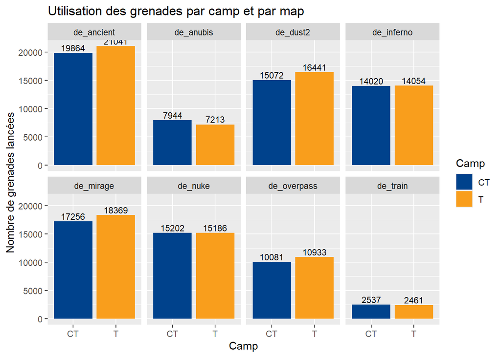

Malgré que l’on retrouve la tendance générale sur la majorité des cartes du jeu, on constate un équilibrage sur la carte Train (le nombre de données étant limité sur cette carte, ils ne reflètent pas forcément la réalité), Nuke et Inferno. La carte Anubis se détache des autres avec une légère tendance favorable pour les Contre-Terroristes.

Regardons maintenant la répartition des grenades utilisées.

**Attendu des résultats.** Je pense que l’on va retrouver une grande majorité de grenades fumigènes dû à la pratique de la smoke, sans forcément de prédominance ou schéma particulier pour les autres grenades.

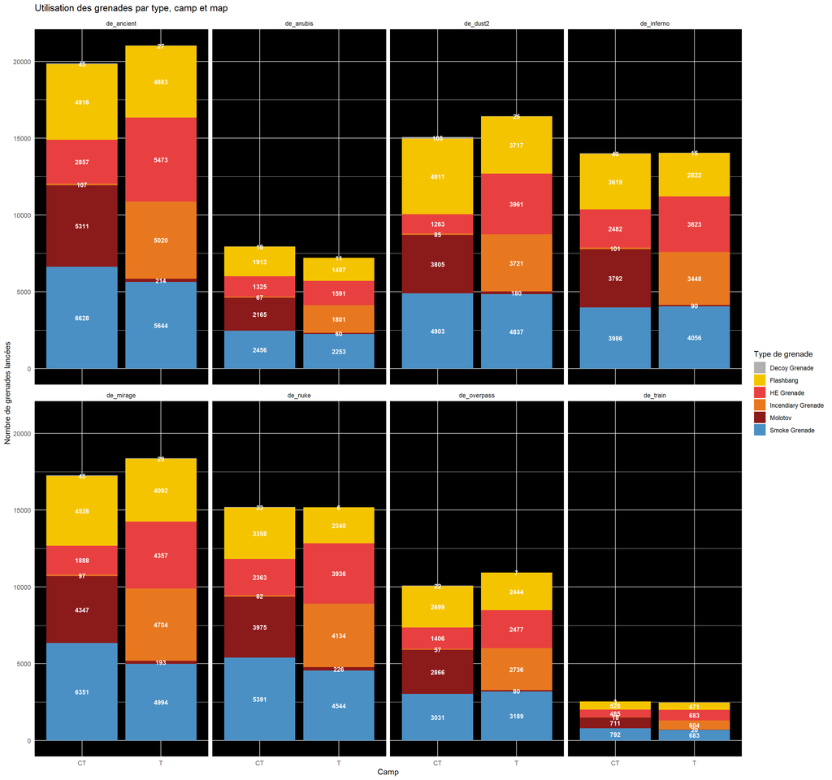

On observe bien que la Smoke Grenade est la plus utilisée par les joueurs, puis la Flashbang. On retrouve ensuite une quantité similaire de grenades Molotov et de grenades Incendiaires, au détail près que les Molotov sont très utilisées par les Contre-Terroristes alors que ce sont les Incendiaires qui sont le plus utilisées par les Terroristes. Les joueurs utilisent également de nombreuses grenades explosives (HE Grenade) et délaissent totalement les grenades de leurres. La répartition diffère légèrement suivant les cartes, mais toutes semblent suivre ce schéma.

À l’échelle des différents types de grenades, il s’avère que la Smoke Grenade est la grenade la plus utilisée tous camps et toutes cartes confondus, suivie de près par la Flashbang, ce qui met en lumière l’importance des déplacements et stratégies dans le jeu.